# 431 Class 06

Thomas E. Love, Ph.D.

2025-09-18

## Today’s Agenda

- Assumptions of our uncertainty intervals for means
  - for one sample / paired differences
  - for two independent samples
- Transforming an Outcome (see [Chapter 7](https://thomaselove.github.io/431-book/))
  - The importance of power transformations
  - Tukey’s ladder and the Box-Cox plot
  - Back-transforming predictions, not coefficients

## Load packages and set theme

```r
library(janitor)
library(patchwork)
library(readxl)
library(knitr)
library(kableExtra)
library(MKinfer)
library(rstanarm)
library(car)         ## new today
library(infer)       ## new today
library(easystats)
library(tidyverse)

theme_set(theme_bw())
knitr::opts_chunk$set(comment = NA)

source("c06/data/Love-431.R") # for the lovedist() function
```

## Our data: from `dm464` again

```r
class06 <- read_xlsx("c06/data/dm464.xlsx") |>
  janitor::clean_names() |>
  select(id_code, age = age_start, sex, home = home_start,
          a1c_base = a1c_start, a1c_end, ldl = ldl_start,
          statin = statin_start) |>
  mutate(across(where(is.character), as_factor)) |>
  mutate(id_code = as.character(id_code)) |>
  mutate(stat_f = as_factor(statin),
         stat_f = fct_recode(stat_f, "Statin" = "1", "No" = "0"))
```

- Read in the Excel data, then clean names and select (and rename some) variables.
- Change all character variables to factors, except `id_code`.
- Create a “Statin”/“No” factor for the 1/0 data in `statin`.

## The `class06` data

```r
class06
```

```
# A tibble: 464 × 9
   id_code   age sex    home    a1c_base a1c_end   ldl statin stat_f
   <chr>   <dbl> <fct>  <fct>      <dbl>   <dbl> <dbl>  <dbl> <fct>
 1 DM-1007    63 Female City         9.5     9     203      1 Statin
 2 DM-1017    56 Male   Suburbs      6.2     6.5    88      1 Statin
 3 DM-1039    53 Female City         6.6     7     139      1 Statin
 4 DM-1049    52 Female City         7       6.7   188      1 Statin
 5 DM-1064    55 Female City         5.3     5.6   112      0 No
 6 DM-1070    61 Female City         6.9     7      81      1 Statin
 7 DM-1076    68 Female City        11.1     9.8   167      0 No
 8 DM-1095    56 Female City         8.3     8.8    89      1 Statin
 9 DM-1110    67 Male   City        10.5    13.1   135      1 Statin
10 DM-1143    64 Female City         5.7     5.4    68      0 No
# ℹ 454 more rows
```

# Uncertainty Interval Assumptions in One Sample / Paired Samples

## One Sample (maybe Paired Differences)

- All approaches assume our sample is a **random** sample (or at least a representative one) from the population of interest.
- Ordinary Least Squares model / Paired T test also assumes that the population of interest follows a Normal distribution, so that our sample data should look as though it were drawn from a Normal distribution.

## One Sample (maybe Paired Differences)

- Our Bayesian approach assumes a (weakly informative) prior distribution on the coefficient in our model.
- The bootstrap approach does not assume a Normal distribution for the population.

Main check in data: Normal distribution?

## Does a Normal model fit well?

**Don’t** rely on hypothesis tests of whether data follow a Normal distribution. Instead, do we have…

1. A histogram that is symmetric and bell-shaped.
2. A boxplot where the box is symmetric around the median, as are the whiskers, without severe outliers.
3. A normal Q-Q plot that essentially falls on a straight line.
4. If in doubt, maybe compare mean and sd to median and MAD, and perhaps consider Empirical Rule.

## Difference in A1c (end - baseline)

```r
class06 <- class06 |> mutate(a1c_diff = a1c_end - a1c_base)

p1 <- ggplot(class06, aes(sample = a1c_diff)) +
  geom_qq() + geom_qq_line(col = "red") +
  labs(y = "A1c difference (%)", x = "Standard Normal Distribution",
    title = "Normal Q-Q plot")

bw = 1 # specify width of bins in histogram

p2 <- ggplot(class06, aes(x = a1c_diff)) +
  geom_histogram(binwidth = bw, fill = "black", col = "yellow") +
  stat_function(fun = function(x)
    dnorm(x, mean = mean(class06$a1c_diff, na.rm = TRUE),
          sd = sd(class06$a1c_diff, na.rm = TRUE)) *
          length(class06$a1c_diff) * bw,
    geom = "area", alpha = 0.5,
    fill = "lightblue", col = "blue") +
  labs(x = "A1c difference (%)", y = "Count",
       title = "Histogram & Normal Curve")

p1 + p2 +
  plot_annotation("Are differences in Hemoglobin A1c Normally distributed?")
```

## Difference in A1c (end - baseline)

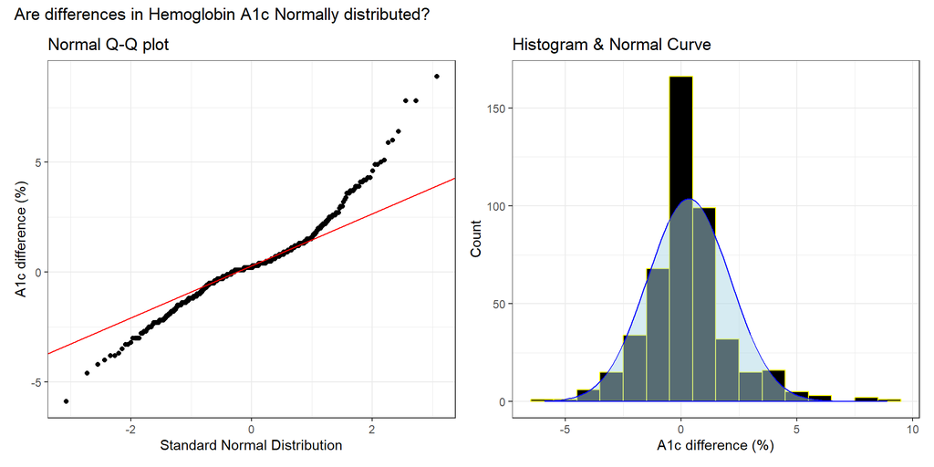

## Boxplot for Difference in A1c

```r
ggplot(class06, aes(x = a1c_diff, y = "")) +
  geom_violin(fill = "cornsilk") +
  geom_boxplot(width = 0.2) +
  stat_summary(fun = mean, geom = "point", shape = 16, col = "red") +
  labs(y = "", x = "A1c difference (%)", title = "Boxplot with Violin")
```

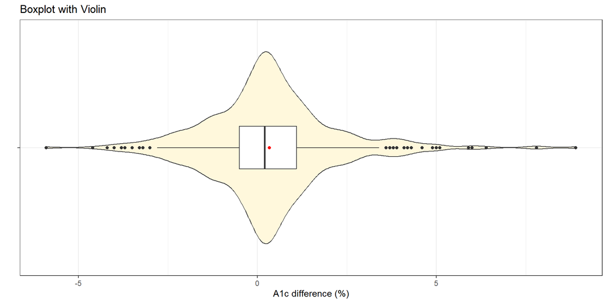

## OLS/t test vs. Bayes

```r
fit1 <- lm(a1c_diff ~ 1, data = class06)
model_parameters(fit1, ci = 0.9)
```

```
Parameter   | Coefficient |   SE |       90% CI | t(463) |      p
-----------------------------------------------------------------
(Intercept) |        0.33 | 0.08 | [0.20, 0.47] |   4.00 | < .001
```

```r
set.seed(43120251)
fit2 <- stan_glm(a1c_diff ~ 1, data = class06, refresh = 0)
model_parameters(fit2, ci = 0.9)
```

```
Parameter   | Median |       90% CI |   pd |  Rhat |  ESS |                 Prior
---------------------------------------------------------------------------------
(Intercept) |   0.33 | [0.19, 0.47] | 100% | 1.000 | 2651 | Normal (0.33 +- 4.46)
```

| Method | Estimate | 90% Uncertainty Interval |
| --- | --- | --- |
| OLS/t | 0.33 | (0.20, 0.47) |
| Bayes | 0.33 | (0.19, 0.47) |

## Bootstrapped t test

```r
set.seed(43120252)
boot.t.test(class06$a1c_diff, conf.level = 0.90, R = 2000)
```

```
    Bootstrap One Sample t-test

data:  class06$a1c_diff
number of bootstrap samples:  2000
bootstrap p-value < 5e-04
bootstrap mean of x (SE) = 0.3285524 (0.08272528)
90 percent bootstrap percentile confidence interval:
 0.1920259 0.4674677

Results without bootstrap:
t = 4.0016, df = 463, p-value = 7.323e-05
alternative hypothesis: true mean is not equal to 0
90 percent confidence interval:
 0.1950719 0.4682901
sample estimates:
mean of x
 0.331681
```

## What to do about outliers? (1/3)

The paired differences here appear to be symmetric, but with outliers.

- This should push us towards a method which doesn’t require the assumption of Normality.
  - Specifically, the bootstrap would likely be a better choice than a t test, although it didn’t make a meaningful difference.
  - 90% uncertainty interval with OLS/t test was (0.20, 0.47) and the bootstrap 90% uncertainty interval was also (0.19, 0.47).

## What to do about outliers? (2/3)

```r
class06 |> reframe(lovedist(a1c_diff)) |>
  kable(digits = 2) |> kable_styling(font_size = 28)
```

| n | miss | mean | sd | med | mad | min | q25 | q75 | max |
| --- | --- | --- | --- | --- | --- | --- | --- | --- | --- |
| 464 | 0 | 0.33 | 1.79 | 0.2 | 1.19 | -5.9 | -0.5 | 1.1 | 8.9 |

- **skew<sub>1</sub>** = (mean - median)/sd = (0.33 - 0.2)/1.79 = 0.073

Could we transform these data in a non-linear way to better match assumptions?

- Not really, no. Most of the transformations we use regularly are designed to address skew in the data, rather than tail behavior.

## What to do about outliers? (3/3)

Should we build our interval around the median instead of the mean?

- sample median = 0.2, sample mean = 0.33

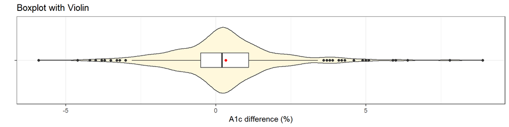

- Maybe, but does that actually address the issue here?

## Bootstrap 90% interval for Median

This is from the `infer` package…

```r
set.seed(431)
x_med <- class06 |> observe(response = a1c_diff, stat = "median")
res1 <- class06 |>
  specify(response = a1c_diff) |>
  generate(reps = 2000, type = "bootstrap") |>
  calculate(stat = "median") |>
  get_confidence_interval(level = 0.90, type = "percentile")

res1 <- res1 |> mutate(pt_est = x_med$stat) |>
  relocate(pt_est)
res1 |> kable()
```

| pt_est | lower_ci | upper_ci |
| --- | --- | --- |
| 0.2 | 0.2 | 0.3 |

## A Strategy for Paired Samples

Suppose we want to estimate an uncertainty interval for the mean of a set of paired differences.

- Calculate the paired differences, then plot them.
- If the sample data are well described as “Normal”, then use the OLS / paired t procedure to obtain a confidence interval, or a Bayesian model to obtain a credible interval.
- If the sample data are best described as “symmetric but with outliers”, then use the bootstrap to obtain a confidence interval, although an OLS or Bayesian result may be quite similar.
- If the sample data are best described as “substantially skewed”, then consider whether you actually want to summarize with the mean, and consider whether a transformation of the outcome might be helpful.

# Uncertainty Interval Assumptions in Independent Samples

## Two Independent Samples (1/2)

- All methods assume each of the two samples is a random sample (or at least representative) of its population.
- Ordinary Least Squares model / Pooled T test assumes:
  - **each** of the two populations of interest follows a Normal distribution, **and**
  - **either** the variance of those two populations is equal, so it makes sense to pool the standard deviations, **or** the sample sizes are equal (a balanced design)

## Two Independent Samples (2/2)

- The Welch t test makes the Normality assumption, but not the assumption of equal population variances.
- Our Bayesian approach assumes a (weakly informative) prior distribution on each of the coefficients (intercept and slope) of our model.
- The bootstrap approach does not assume a Normal distribution for the population, but can take advantage of an assumption of equal variances if it exists.

## LDL means by `statin` group (1/5)

**OLS / pooled t**

```r
fit3 <- lm(ldl ~ stat_f, data = class06)
model_parameters(fit3, ci = 0.90)
```

```
Parameter       | Coefficient |   SE |          90% CI | t(462) |      p
------------------------------------------------------------------------
(Intercept)     |       96.26 | 3.86 | [89.90, 102.62] |  24.94 | < .001
stat f [Statin] |        7.17 | 4.34 | [ 0.02,  14.32] |   1.65 | 0.099
```

## LDL means by `statin` group (2/5)

**Welch t (no pooling)**

```r
fit4 <- t.test(ldl ~ stat_f, data = class06,
               var.equal = FALSE, conf.level = 0.90)
model_parameters(fit4, ci = 0.90)
```

```
Welch Two Sample t-test

Parameter |  Group | stat_f = No | stat_f = Statin | Difference
---------------------------------------------------------------
ldl       | stat_f |       96.26 |          103.43 |      -7.17

Parameter |          90% CI | t(183.36) |     p
-----------------------------------------------
ldl       | [-13.48, -0.86] |     -1.88 | 0.062

Alternative hypothesis: true difference in means between group No and group Statin is not equal to 0
```

## LDL means by `statin` group (3/5)

**Bayesian linear model**

```r
set.seed(43105)
fit5 <- stan_glm(ldl ~ stat_f, data = class06, refresh = 0)
model_parameters(fit5, ci = 0.90)
```

```
Parameter    | Median |          90% CI |     pd |  Rhat |  ESS |                    Prior
------------------------------------------------------------------------------------------
(Intercept)  |  96.17 | [89.91, 102.31] |   100% | 1.000 | 4149 | Normal (101.93 +- 95.20)
stat_fStatin |   7.26 | [ 0.11,  14.48] | 95.17% | 1.000 | 4194 |  Normal (0.00 +- 233.87)
```

## LDL means by `statin` group (4/5)

**Bootstrap, without pooling sd estimates**

```r
set.seed(43106)
boot.t.test(ldl ~ stat_f, var.equal = FALSE, R = 2000,
  data = class06, conf.level = 0.90)
```

```
    Bootstrap Welch Two Sample t-test

data:  ldl by stat_f
number of bootstrap samples:  2000
bootstrap p-value = 0.07
bootstrap difference of means (SE) = -7.156579 (3.782602)
90 percent bootstrap percentile confidence interval:
 -13.02256  -1.16262

Results without bootstrap:
t = -1.8786, df = 183.36, p-value = 0.06188
alternative hypothesis: true difference in means is not equal to 0
90 percent confidence interval:
 -13.4797701  -0.8603518
sample estimates:
    mean in group No mean in group Statin
            96.25773            103.42779
```

## LDL means by `statin` group (5/5)

**Bootstrap, with pooling of sd estimates**

```r
set.seed(43107)
boot.t.test(ldl ~ stat_f, var.equal = TRUE, R = 2000,
  data = class06, conf.level = 0.90)
```

```
    Bootstrap Two Sample t-test

data:  ldl by stat_f
number of bootstrap samples:  2000
bootstrap p-value = 0.11
bootstrap difference of means (SE) = -7.356209 (4.338503)
90 percent bootstrap percentile confidence interval:
 -14.54414309   0.01876738

Results without bootstrap:
t = -1.6523, df = 462, p-value = 0.09915
alternative hypothesis: true difference in means is not equal to 0
90 percent confidence interval:
 -14.32216921  -0.01795271
sample estimates:
    mean in group No mean in group Statin
            96.25773            103.42779
```

## Findings So Far…

Estimating the mean difference in LDL levels at baseline for the “Statin” group minus the “No Statin” group…

[output not shown]

## LDL by Statin prescription status

We’ll start with a comparison boxplot.

```r
ggplot(class06, aes(x = ldl, y = stat_f)) +
  geom_violin() +
  geom_boxplot(aes(fill = stat_f), width = 0.3) +
  stat_summary(fun = mean, geom = "point",
               shape = 18, size = 4, col = "black") +
  guides(fill = "none") +
  labs(y = "Statin prescription", x = "LDL Cholesterol (mg/dl)",
       title = "LDL by Statin prescription",
       subtitle = "Each group is a bit skewed to the right")
```

## LDL by Statin prescription status

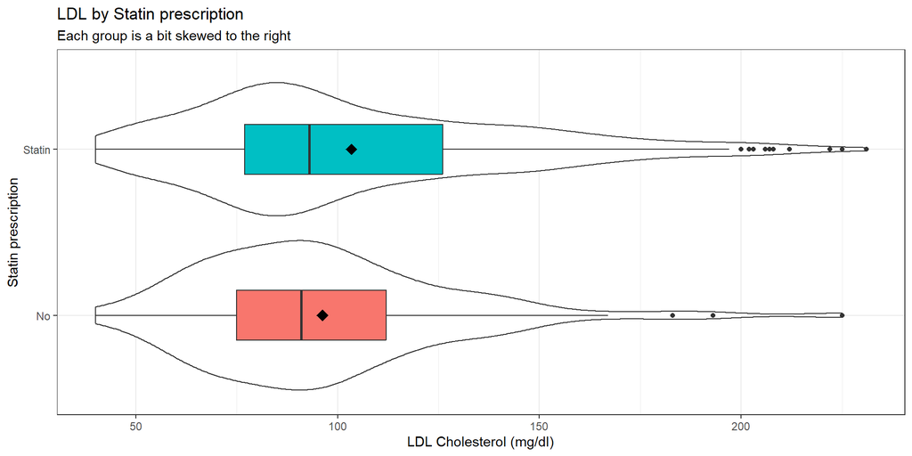

## LDL by Statin prescription status

How about a pair of Normal Q-Q plots?

```r
p1 <- class06 |>
  filter(stat_f == "Statin") |>
  ggplot(aes(sample = ldl)) +
  geom_qq() + geom_qq_line(col = "red") +
  labs(title = "Statin group", y = "LDL Cholesterol (mg/dl)",
        x = "Standard Normal")

p2 <- class06 |>
  filter(stat_f == "No") |>
  ggplot(aes(sample = ldl)) +
  geom_qq() + geom_qq_line(col = "red") +
  labs(title = "No Statin group", y = "LDL Cholesterol (mg/dl)",
        x = "Standard Normal")

p1 + p2 +
  plot_annotation(title = "Normal Q-Q plots of LDL by Statin group")
```

## LDL by Statin prescription status

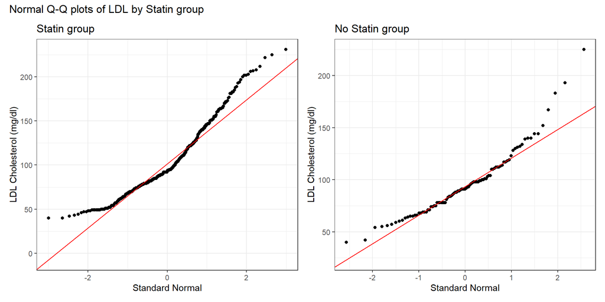

## LDL by Statin prescription status

A look at some numerical summaries…

```r
class06 |> group_by(stat_f) |> reframe(lovedist(ldl)) |>
  kable(digits = 2) |> kable_styling(font_size = 28)
```

| stat_f | n | miss | mean | sd | med | mad | min | q25 | q75 | max |
| --- | --- | --- | --- | --- | --- | --- | --- | --- | --- | --- |
| No | 97 | 0 | 96.26 | 31.63 | 91 | 28.17 | 40 | 75 | 112 | 225 |
| Statin | 367 | 0 | 103.43 | 39.51 | 93 | 34.10 | 40 | 77 | 126 | 231 |

- skew<sub>1</sub> for “Statin” = (103.43 - 93)/39.51 = 0.26
- skew<sub>1</sub> for “No” = (96.26 - 91)/31.63 = 0.17

Our rough cutoff for substantial right skew ~ 0.20.

## What can we do about the skew?

- Could we build a confidence interval for medians instead of means?
  - Yes, with the bootstrap, for example see [Section 6.9.2](https://thomaselove.github.io/431-book/06_twogroups.html#bootstrap-ci-for-medians) of my text.
- Could we transform the data in a non-linear way to better match assumptions?
  - Yes, with the help of **Tukey’s ladder** of power transformations.

## Tukey’s Ladder

| Power ($\lambda$) | -2 | -1 | -0.5 | 0 | 0.5 | 1 | 2 | 3 |
| --- | --- | --- | --- | --- | --- | --- | --- | --- |
| Transformation | $\frac{1}{y^2}$ | $\frac{1}{y}$ | $\frac{1}{\sqrt{y}}$ | log $y$ | $\sqrt{y}$ | $y$ | $y^2$ | $y^3$ |

- Works to address skew, mainly, rather than symmetry with problems in the tails
- Some of these transformations require all values to be positive. If they aren’t, we can add a small amount to each observation until they are.
- Start at no transformation ($\lambda = 1$)
- Try moving in one direction or the other, searching for a result which better matches what we might expect from a Normal distribution
  - If a step (like taking the square root) helps, move in that same direction.
  - If it doesn’t help, try moving in the other direction.

## A1c values (end of study)

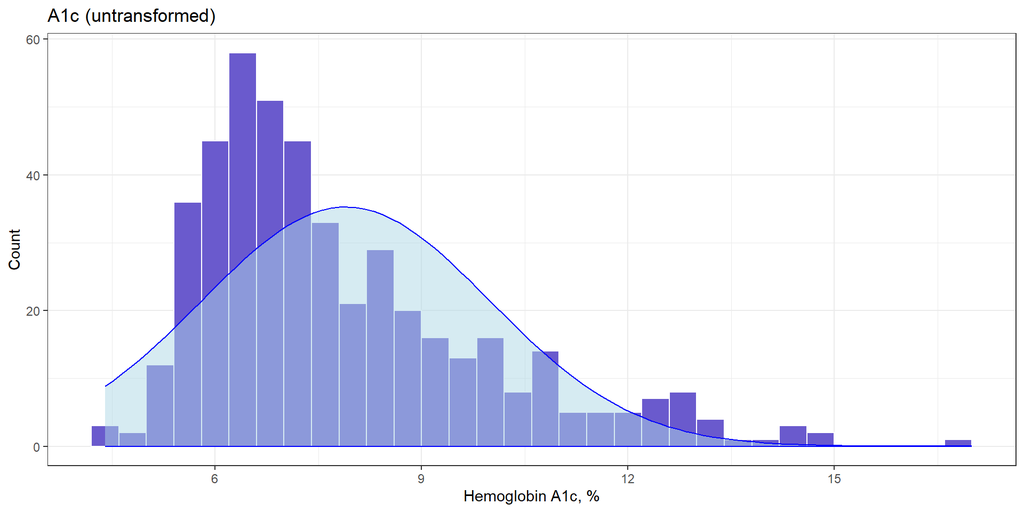

## Six Power Transformations

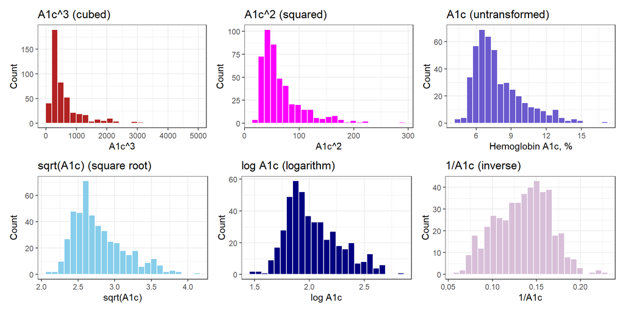

## Which Transformation to Choose?

Box-Cox approach: can we get a suggested “power” to use when transforming our outcome?

- Specify the model then apply `boxCox` from `car` package.
- Here, all values of our outcome (A1c) are strictly positive.
  - If not, we’d have to add a constant so that they were.

```r
fit1 <- lm(a1c_end ~ 1, data = class06)
boxCox(fit1)
```

## Which Transformation to Choose?

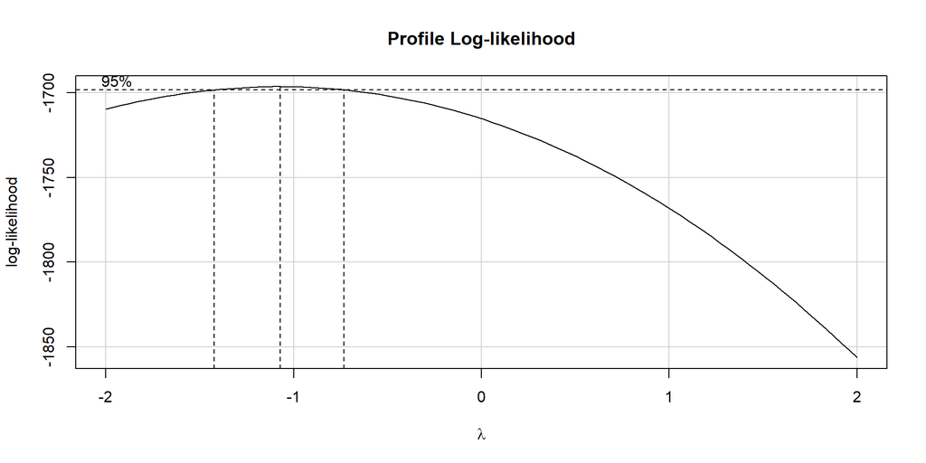

## Back to LDL by Statin prescription

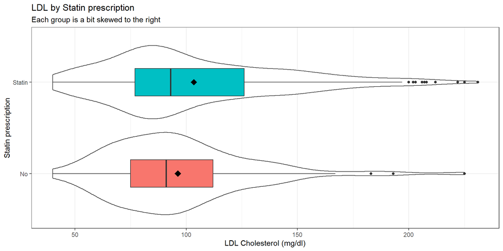

## What transformation should we try?

```r
fit2 <- lm(ldl ~ statin, data = class06)
boxCox(fit2)
```

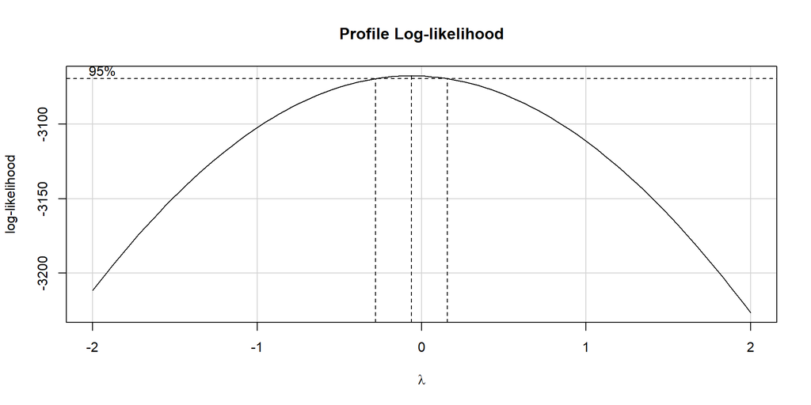

## log(LDL) by Statin?

```r
ggplot(class06, aes(x = log(ldl), y = stat_f)) +
  geom_violin() +
  geom_boxplot(aes(fill = stat_f), width = 0.3) +
  stat_summary(fun = mean, geom = "point",
               shape = 18, size = 4, col = "black") +
  labs(y = "Statin prescription", x = "log(LDL)",
       title = "log(LDL) by Statin prescription") +
  guides(fill = "none")
```

## log(LDL) by Statin?

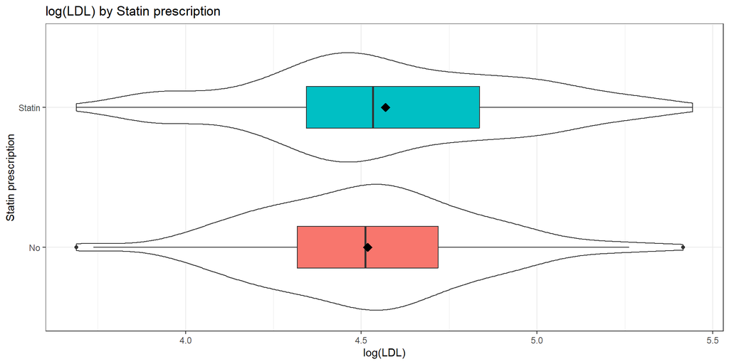

## Estimate log(LDL) mean by Statin

```r
fit3 <- lm(log(ldl) ~ stat_f, data = class06)
model_parameters(fit3, ci = 0.90)  ## 90% uncertainty interval
```

```
Parameter       | Coefficient |   SE |        90% CI | t(462) |      p
----------------------------------------------------------------------
(Intercept)     |        4.52 | 0.04 | [ 4.46, 4.58] | 122.75 | < .001
stat f [Statin] |        0.05 | 0.04 | [-0.02, 0.12] |   1.23 | 0.220
```

```
Uncertainty intervals (equal-tailed) and p-values (two-tailed) computed
  using a Wald t-distribution approximation.
```

```
The model has a log-transformed response variable. Consider using
  `exponentiate = TRUE` to interpret coefficients as ratios.
```

- The difference between Statin and No Statin on the logarithmic scale (in mean of log(LDL)) is thus 0.05, with 90% CI (-0.02, 0.12).

## Expectations from our model

- The model coefficients exist in the transformed world, but we can make predictions back on our original scale.

```r
estimate_expectation(fit3, data = "grid", ci = 0.90)
```

```
Model-based Predictions

stat_f | Predicted |   SE |       90% CI
----------------------------------------
No     |      4.52 | 0.04 | [4.46, 4.58]
Statin |      4.57 | 0.02 | [4.54, 4.60]

Variable predicted: ldl
Predictors modulated: stat_f
Predictions are on the log-scale (consider `transform=TRUE`).
```

- and we exponentiate to get back to our original scale…

## Expectations from our model

- We use `transform = TRUE` to exponentiate back out of the logarithms to our original scale of LDL cholesterol levels.

```r
estimate_expectation(fit3, data = "grid", ci = 0.90, transform = TRUE)
```

```
Model-based Predictions

stat_f | Predicted |         90% CI
-----------------------------------
No     |     91.67 | [86.27, 97.40]
Statin |     96.45 | [93.49, 99.50]

Variable predicted: ldl
Predictors modulated: stat_f
```

## Exponentiation of Expectations

- Back out of logged predictions by exponentiating…

| Group | Predicted LDL | 90% uncertainty interval |
| --- | --- | --- |
| No Statin | exp(4.52) = 91.8 | (exp(4.46), exp(4.58)) = (86.5, 97.5) |
| Statin | exp(4.57) = 96.5 | (exp(4.54), exp(4.60)) = (93.7, 99.5) |

- These intervals describe uncertainty about the **average predicted LDL across all subjects** in each statin group.

## Fitting Individual Predictions

- Use `estimate_prediction()` to make predictions for an individual subject in each group.

```r
estimate_prediction(fit3, data = "grid", ci = 0.90)
```

```
Model-based Predictions

stat_f | Predicted |   SE |       90% CI
----------------------------------------
No     |      4.52 | 0.36 | [3.92, 5.12]
Statin |      4.57 | 0.36 | [3.97, 5.17]

Variable predicted: ldl
Predictors modulated: stat_f
Predictions are on the log-scale (consider `transform=TRUE`).
```

- and exponentiate to get back to our original scale…

## Fitting Individual Predictions

- Back out of log transformation with `transform = TRUE`.

```r
estimate_prediction(fit3, data = "grid", ci = 0.90, transform = TRUE)
```

```
Model-based Predictions

stat_f | Predicted |          90% CI
------------------------------------
No     |     91.67 | [50.28, 167.12]
Statin |     96.45 | [53.02, 175.44]

Variable predicted: ldl
Predictors modulated: stat_f
```

## Fitting Individual Predictions

- Exponentiating the predictions gives…

| Group | Predicted LDL | 90% uncertainty interval |
| --- | --- | --- |
| No Statin | exp(4.52) = 91.8 | (exp(3.92), exp(5.12)) = (50.4, 167.3) |
| Statin | exp(4.57) = 96.5 | (exp(3.97), exp(5.17)) = (53, 175.9) |

- These intervals describe uncertainty about an **individual predicted LDL for a single subject** in each group.

## Using the log transformation

- The log transformation in R (`log` in R is the natural log - the base 10 log is `log10()`) generates coefficients which describe a multiplicative effect.

If we fit a model to predict $y$ using $x$ of the form:

$$\log y = \beta_0 + \beta_1 x$$

where $\log y$ is the natural log, then if we exponentiate the slope coefficient, we get the multiplicative factor for a one-unit increase in the predictor.

## The Math

$$\log(y) = \beta_0 + \beta_1 x \\
\exp(\log(y)) = \exp(\beta_0 + \beta_1 x) \\
y = \exp(\beta_0 + \beta_1 x) \\
y = \exp(\beta_0) \times \exp(\beta_1 x)$$

This implies that our predictor ($x$) has a multiplicative relationship with our outcome ($y$) instead of the usual additive relationship. Hence, we can express the effect of a one-unit change in $x$ on $y$ as a percentage change.

## Example 1

Suppose we build a regression model with equation $\log y = 6 + 0.23 x$.

Note that $\exp(0.23) = 1.26$.

- If Harry’s value of $x$ is 1 point larger than Sally’s, the predicted $y$ value for Harry will be increased by 26% relative to Sally’s. (Increased by 26% = multiplied by 1.26.)

## Back to log(LDL) by Statin

```r
fit3 <- lm(log(ldl) ~ stat_f, data = class06)
model_parameters(fit3, ci = 0.90)  ## 90% uncertainty interval
```

```
Parameter       | Coefficient |   SE |        90% CI | t(462) |      p
----------------------------------------------------------------------
(Intercept)     |        4.52 | 0.04 | [ 4.46, 4.58] | 122.75 | < .001
stat f [Statin] |        0.05 | 0.04 | [-0.02, 0.12] |   1.23 | 0.220
```

- Now, we’ll exponentiate these coefficients…

## Exponentiating the Coefficients

```r
fit3 <- lm(log(ldl) ~ stat_f, data = class06)
model_parameters(fit3, ci = 0.90, exponentiate = TRUE)
```

```
Parameter       | Coefficient |   SE |         90% CI | t(462) |      p
-----------------------------------------------------------------------
(Intercept)     |       91.67 | 3.37 | [86.27, 97.40] | 122.75 | < .001
stat f [Statin] |        1.05 | 0.04 | [ 0.98,  1.13] |   1.23 | 0.220
```

Subjects *with* a statin prescription have 5% higher LDL, on average, than do subjects *without*.

- The ratio has point estimate 1.05 and 90% interval estimate (0.98, 1.13).

## Independent Samples Strategy

Suppose we want to estimate an uncertainty interval for the difference in means across two groups. To begin, plot the data from each sample.

- If the sample data in each group are well described as “Normal”, then use the OLS / pooled t procedure to obtain a confidence interval, or a Bayesian model to obtain a credible interval.
  - If the sample sizes are not the same, and the sample variances aren’t close to each other, consider using a Welch t procedure.
- If either sample’s data are “symmetric but with outliers”, then consider using the bootstrap to obtain a confidence interval, although an OLS or Bayesian result may also be reasonable.
- If either sample’s data are best described as “substantially skewed”, then consider whether you actually want to summarize with the difference in means, and consider whether a transformation might be helpful.

# Another worked example (for self-study)

## Boxplot: Difference in A1c by Sex

```r
ggplot(class06, aes(x = a1c_diff, y = sex)) +
  geom_violin() + geom_boxplot(aes(fill = sex), width = 0.3) +
  labs(x = "Change in A1c", y = "Sex",
       title = "Difference in A1c (end - base) by Sex") +
  guides(fill = "none")
```

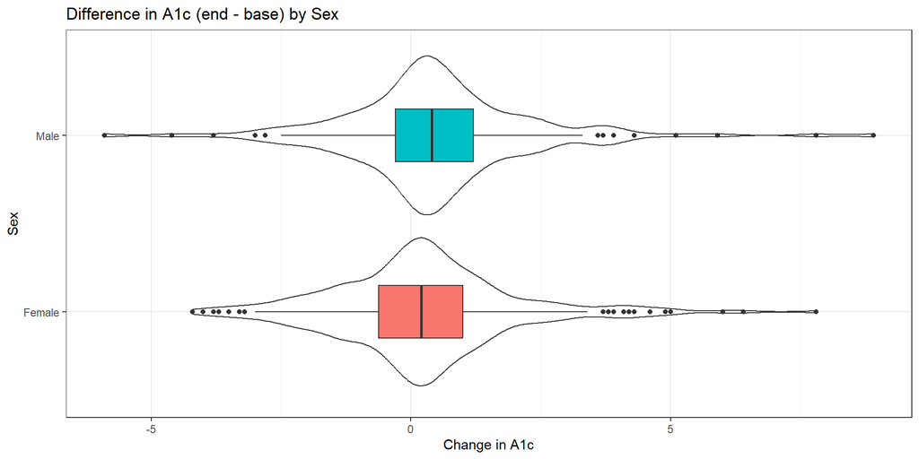

## Numerical Summary (A1c by Sex)

```r
class06 |> group_by(sex) |>
  reframe(lovedist(a1c_diff)) |>
  kable(digits = 3) |> kable_styling(font_size = 28)
```

| sex | n | miss | mean | sd | med | mad | min | q25 | q75 | max |
| --- | --- | --- | --- | --- | --- | --- | --- | --- | --- | --- |
| Female | 288 | 0 | 0.227 | 1.747 | 0.2 | 1.186 | -4.2 | -0.625 | 1.0 | 7.8 |
| Male | 176 | 0 | 0.503 | 1.838 | 0.4 | 1.186 | -5.9 | -0.300 | 1.2 | 8.9 |

- Difference in sample means is 0.503 - 0.227 = 0.276
- Do we have a balanced design?
- Are we comfortable pooling standard deviations?
- Are we comfortable assuming Normality for each sex?

## Might a transformation help here?

Some of the A1c changes are negative (minimum = -5.9)

```r
class06 <- class06 |> mutate(a1c_diff_p6 = a1c_diff + 6)
fit4 <- lm(a1c_diff_p6 ~ sex, data = class06)
boxCox(fit4)
```

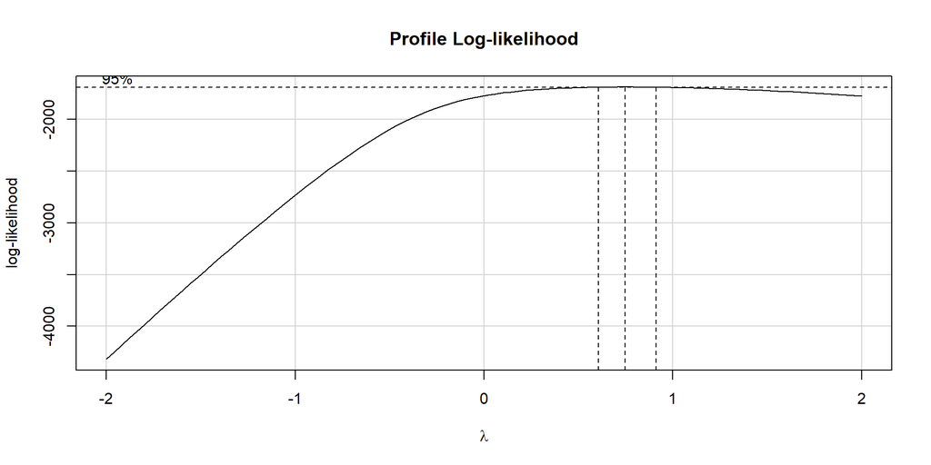

## Does using a square root help?

```r
p1 <- ggplot(class06, aes(x = a1c_diff_p6, y = sex)) +
  geom_violin() + geom_boxplot(aes(fill = sex), width = 0.3) +
  labs(x = "Change in A1c + 6", y = "Sex",
       title = "A1c difference (+ 6) by Sex") +
  guides(fill = "none")

p2 <- ggplot(class06, aes(x = sqrt(a1c_diff_p6), y = sex)) +
  geom_violin() + geom_boxplot(aes(fill = sex), width = 0.3) +
  labs(x = "Square Root of (Change in A1c + 6)", y = "Sex",
       title = "Square Root of (A1c difference + 6) by Sex") +
  guides(fill = "none")

p1 / p2
```

## Does using a square root help?

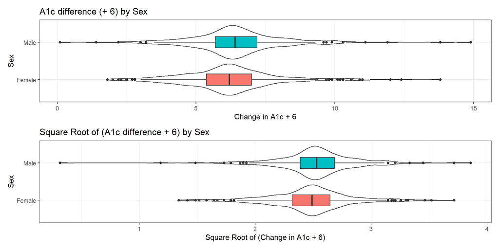

## Addressing outliers?

### OLS model

```r
fit5 <- lm(a1c_diff ~ sex, data = class06)

model_parameters(fit5, ci = 0.90)
```

```
Parameter   | Coefficient |   SE |        90% CI | t(462) |     p
-----------------------------------------------------------------
(Intercept) |        0.23 | 0.11 | [ 0.05, 0.40] |   2.16 | 0.031
sex [Male]  |        0.28 | 0.17 | [ 0.00, 0.56] |   1.62 | 0.105
```

- Male subjects had A1c changes that were 0.28 larger than females, on average, with 90% uncertainty interval (0, 0.56) according to our OLS model (pooled t test.)

## Addressing outliers?

### Bayesian model

```r
set.seed(20240912)
fit6 <- stan_glm(a1c_diff ~ sex, data = class06, refresh = 0)

model_parameters(fit6, ci = 0.90)
```

```
Parameter   | Median |        90% CI |     pd |  Rhat |  ESS |                 Prior
------------------------------------------------------------------------------------
(Intercept) |   0.22 | [ 0.05, 0.39] | 98.42% | 1.000 | 3666 | Normal (0.33 +- 4.46)
sexMale     |   0.28 | [ 0.00, 0.57] | 94.80% | 1.000 | 3649 | Normal (0.00 +- 9.19)
```

- Male subjects had A1c changes that were 0.28 larger than females, on average, with 90% uncertainty interval (0, 0.57) according to our Bayesian model.

## Addressing outliers?

### Bootstrap with `boot.t.test`

```r
set.seed(20240912)
boot.t.test(a1c_diff ~ sex, data = class06, conf.level = 0.90)
```

```
    Bootstrap Welch Two Sample t-test

data:  a1c_diff by sex
number of bootstrap samples:  9999
bootstrap p-value = 0.1096
bootstrap difference of means (SE) = -0.2787276 (0.1715815)
90 percent bootstrap percentile confidence interval:
 -0.566107955  0.002070707

Results without bootstrap:
t = -1.6028, df = 355.56, p-value = 0.1099
alternative hypothesis: true difference in means is not equal to 0
90 percent confidence interval:
 -0.561349458  0.008003498
sample estimates:
mean in group Female   mean in group Male
           0.2267361            0.5034091
```

## Repeating: Paired Samples Strategy

Suppose we want to estimate an uncertainty interval for the mean of a set of paired differences.

- Calculate the paired differences, then plot them.
- If the sample data are well described as “Normal”, then use the OLS / paired t procedure to obtain a confidence interval, or a Bayesian model to obtain a credible interval.
- If the sample data are best described as “symmetric but with outliers”, then use the bootstrap to obtain a confidence interval, although an OLS or Bayesian result may be quite similar.
- If the sample data are best described as “substantially skewed”, then consider whether you actually want to summarize with the mean, and consider whether a transformation might be helpful.

## Independent Samples Strategy

Suppose we want to estimate an uncertainty interval for the difference in means across two groups. To begin, plot the data from each sample.

- If the sample data in each group are well described as “Normal”, then use the OLS / pooled t procedure to obtain a confidence interval, or a Bayesian model to obtain a credible interval.
  - If the sample sizes are not the same, and the sample variances aren’t close to each other, consider using a Welch t procedure.
- If either sample’s data are “symmetric but with outliers”, then consider using the bootstrap to obtain a confidence interval, although an OLS or Bayesian result may also be reasonable.
- If either sample’s data are best described as “substantially skewed”, then consider whether you actually want to summarize with the difference in means, and consider whether a transformation might be helpful.